# Examining Patient Evaluations of Antidepressant Drug Use and Efficacy

Joe Stoica, Conor Devins, Geno Kim

06 December, 2018

# Introduction

According to the 2015 report “Depression and Other Common Mental Disorders: Global Health Estimates” by the World Health Organization, depression is the leading cause of disability and burden of disease worldwide. Evidence-based guidelines generally recommend that second-generation antidepressants (e.g. selective serotonin reuptake inhibitors and selective norepinephrine reuptake inhibitors)—in conjunction with psychotherapy—be taken as the first line of treatment for depression (Anderson et al., 2008; Qaseem, Barry, & Kansagara, 2016; Won et al., 2014). Given the considerably large array of existing pharmacological treatment options for depression and heterogeneity in risk/benefit trade-offs thereof, it is worth examining critical aspects of patients’ subjective treatment experiences across a representative sample of the antidepressant drug landscape.

Research indicates that efforts to maximize treatment benefits for patients with psychiatric illnesses are hampered by poor adherence to prescribed medications (McDonald, Garg, & Haynes, 2002). Among the many different patient factors known to affect adherence to psychiatric treatment (e.g. patient beliefs, stigmas, cost, fears of addiction, etc.), adverse drug side effects are commonly reported as a reason for reluctance to accept or continue pharmacological treatment programs (Fortney et al., 2011; Sansone & Sansone, 2012).

# Statement of goals.

1. What is the relationship between perceived effectiveness, perceived side effects and overall satisfaction?
2. What is the relation between perceived side effects and perceived effectiveness?

## Why should we care?

# Description of your data.

The data we chose to use is the Drug Review Dataset from the UCI Machine Learning Repository. The data focuses on pharmaceutical drug users ratings and written reviews of certain drugs they’ve taken.

Since we are primarily concerned with people diagnosed with depression, we filtered out every user that did not state they had depressions in the self-reported condition. That cut out about 88% of the data, and left us with 499 observations. We then removed the user typed reviews, so were only left with the following columns:

**DrugName**: the name of the drug

**Satisfaction**: Rating (10-point scale, 10 being highest satisfaction)

**Effectiveness**: 1 - Ineffective; 2 - Marginally Effective; 3 - Moderately Effective; 4 - Considerably Effective; 5 - Highly Effective

**Side Effects**: 1 - Extremely Severe Side Effects; 2 - Severe Side Effects; 3 - Moderate Side Effects; 4 - Mild Side Effects; 5 - No Side Effects

**Type**: Chemical type of the drug

Here is a snapshot of our data

| drug | rating | effectiveness | sideEffects | type |
| --- | --- | --- | --- | --- |
| effexor | 1 | 2 | 1 | NRI |
| effexor | 9 | 5 | 4 | NRI |
| lexapro | 3 | 2 | 2 | SRI |
| cymbalta | 7 | 4 | 4 | NRI |
| effexor | 10 | 5 | 5 | NRI |
| paxil | 8 | 4 | 4 | SRI |

We also simplified drug names when necessary. We simplified “wellbutrin-XL” to just “wellbutrin” because it’s the same drug, just higher dosage. The drug type falls into three categories: SRI, NRI, and other. The first two target different chemical receptors in the brain to treat depression. The other category contains seven other drug families, but we condensed them all because their individual counts are so low. These were added independently and were not found in the original data. We also recoded the Likert ratings to be numerical instead of strings for making data manipulation simpler.

# Answering Our Questions.

## Simple EDA

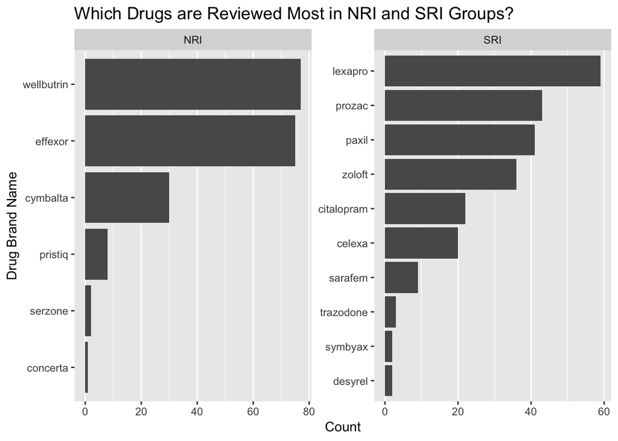

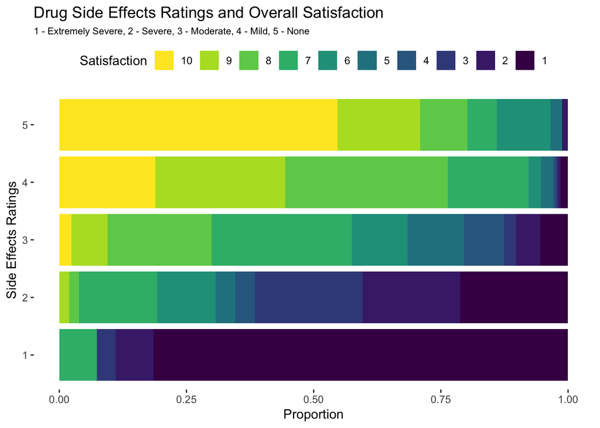

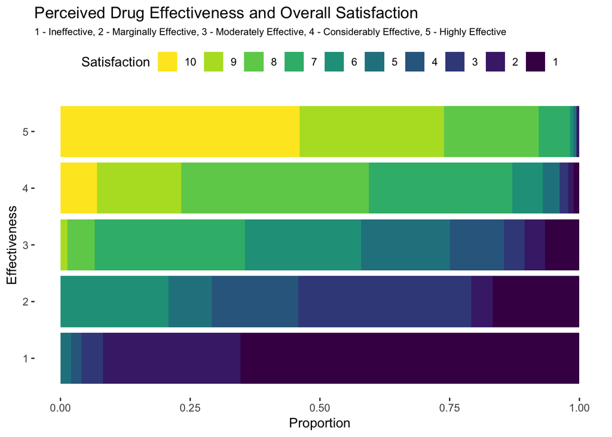

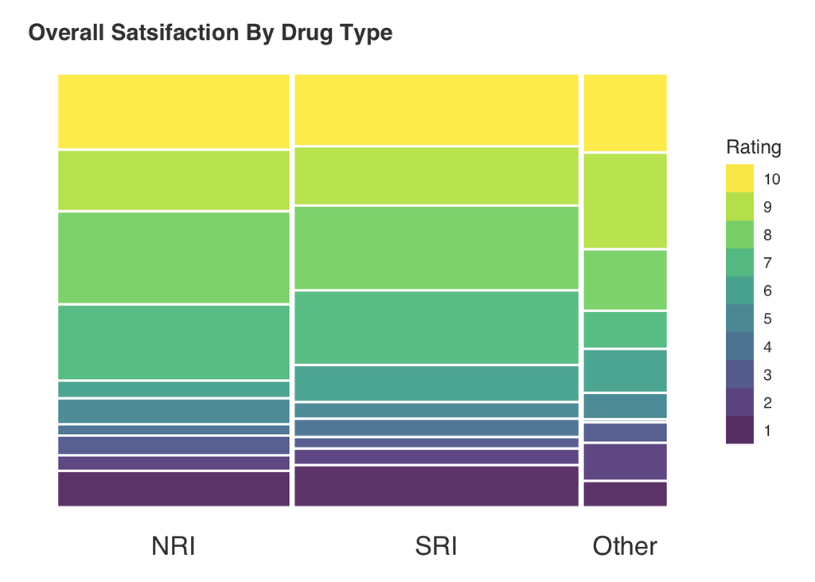

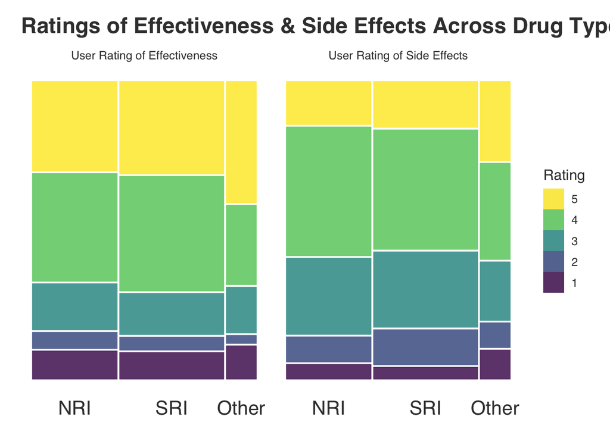

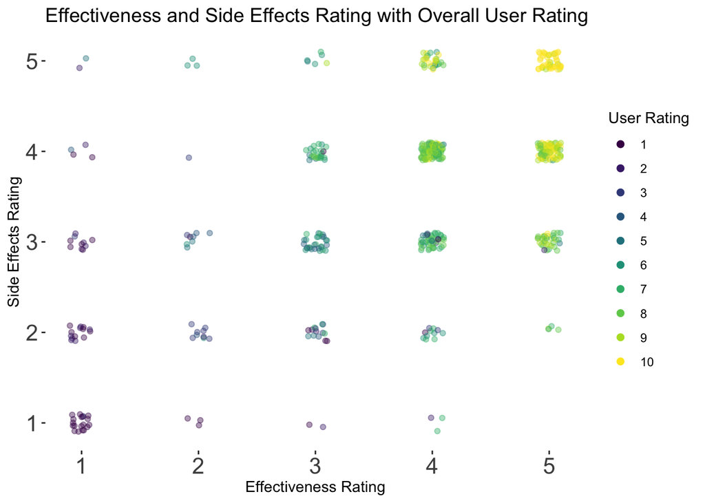

## Model Creation

I created three models all trying to predict rating. They all have side effects and effectiveness. The first model only uses those two, the second model takes into consideration drug type, and the third model takes into consideration the drug itself. The first model has the lowest Akaike information criterion (AIC). “[It] is an estimator of the relative quality of statistical models for a given set of data. Given a collection of models for the data, AIC estimates the quality of each model, relative to each of the other models. Thus, AIC provides a means for model selection.(stolen from wikipedia (https://en.wikipedia.org/wiki/Akaike_information_criterion)”. So even though it doesnt have the lowest residual deviance, it is still the best model to use. Adding the sentiment analysis might improve it, however.

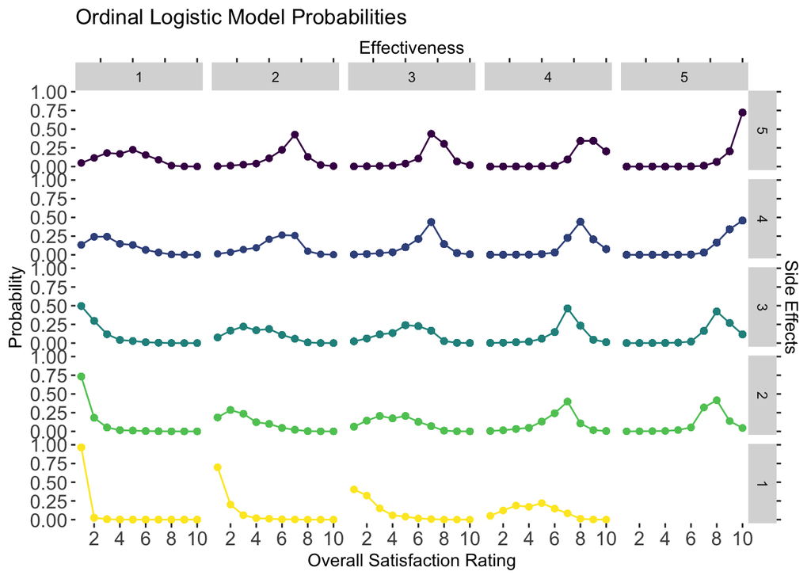

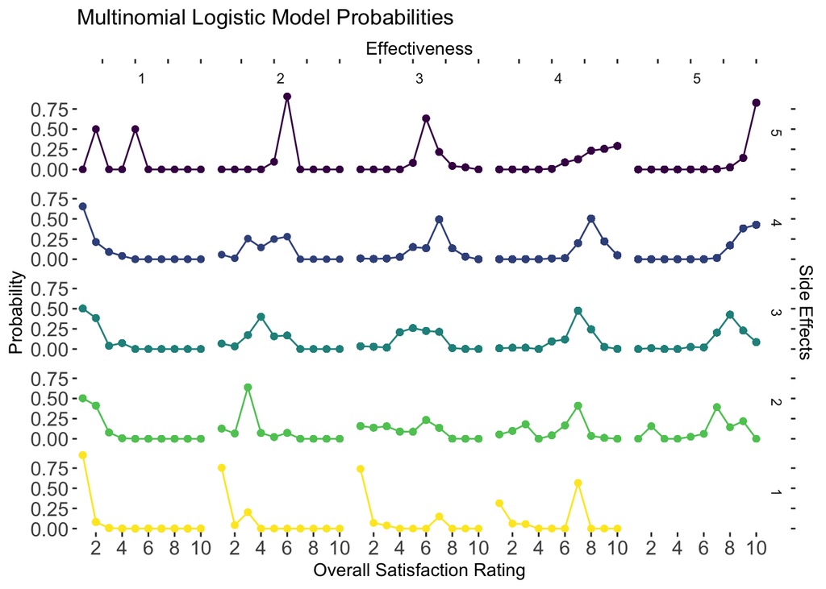

Multinomial logit model 1 and 2 not very different based on AIC (1380.239 vs 1383.26 respectively), whereas model 3 has lowest deviance but considerably higher AIC (1879.28). Could go with multi_mod, since it has lowest AIC.

Show polr plot predicting effectiveness using side effects as predictor; how strongly do side effects predict perceived drug effectiveness?

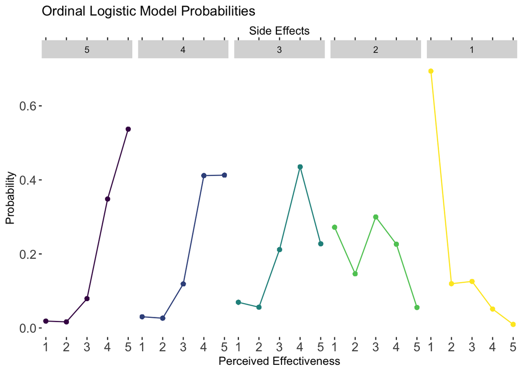

Show polr plot with only single predictor using Side Effects to predict Overall Satisfaction

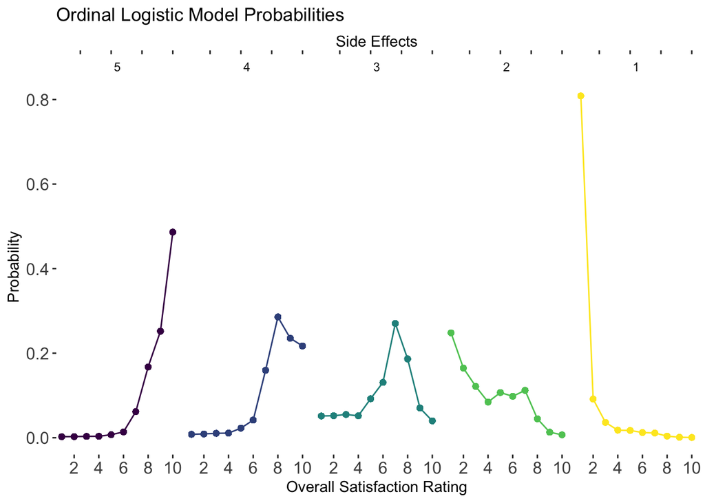

# Identification of work left to do/limitations.